# Factor Analyis: a case study to understand interest rates

Statistical Learning, Bachelor in Data Science and Engineering

UC3M, 2022

[figure not shown]

# Motivation

In this case study, we will apply factor analysis to capture the main drivers of the US economy through its interest rates

The US Government (and most of the governments in the world) pays a **yield** or **interest rate** to borrow money for different time horizons in order to raise money for investing/spending

The Treasury Department issues bonds with maturities ranging from 1 month to 30 years (short term bonds are called T-bills whereas long term ones are called just T-bonds)

The associated yields tell us how investors feel about the economy and help determine the current and future strength of the economy

The **yield curve** joins the different bond yields (interest rates) at different maturity times. Hence, there is one yield curve for each trading day

Yield curve rates are published on the Treasury’s website each trading day. Here the last trading days: https://www.treasury.gov/resource-center/data-chart-center/interest-rates/pages/textview.aspx?data=yield

To understand better the yield curve, take a look at this 3D representation by the New York Times: https://www.nytimes.com/interactive/2015/03/19/upshot/3d-yield-curve-economic-growth.html

We expect that long-term bonds have a higher yield than shorter securities. This is what happens most of the time, but there are three main shapes of yield curve shapes: normal (upward sloping curve), inverted (downward sloping curve), and flat.

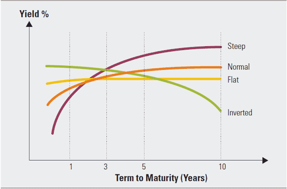

Yield curve

Normal curves point to economic expansion, and downward sloping (inverted) curves point to economic recession

# Load and prepare data

```r
# delete everything
rm(list=ls())

library(tidyverse)
library(VIM)
library(Quandl)
library(VIM)
library(lubridate)
library(GGally)
library(factoextra)
library(quantmod)
```

Get US Treasury yield curves using Quandl Api

Updated data here: https://home.treasury.gov/resource-center/data-chart-center/interest-rates/TextView?type=daily_treasury_yield_curve&field_tdr_date_value=2022

```r
# Using Quandl
#Quandl.api_key("Your-Api-key-here")
yc <- Quandl("USTREASURY/YIELD")

Data = yc[dim(yc)[1]:1,]
Data=rename(Data, date=Date)
date = Data$date

save(Data,file="data.RData")
# End of Quandl
```

```r
# In case you have problems:
load("data.RData")

head(Data)
```

```
##            date 1 MO 2 MO 3 MO 6 MO 1 YR 2 YR 3 YR 5 YR 7 YR 10 YR 20 YR 30 YR
## 8200 1990-01-02   NA   NA 7.83 7.89 7.81 7.87 7.90 7.87 7.98  7.94    NA  8.00
## 8199 1990-01-03   NA   NA 7.89 7.94 7.85 7.94 7.96 7.92 8.04  7.99    NA  8.04
## 8198 1990-01-04   NA   NA 7.84 7.90 7.82 7.92 7.93 7.91 8.02  7.98    NA  8.04
## 8197 1990-01-05   NA   NA 7.79 7.85 7.79 7.90 7.94 7.92 8.03  7.99    NA  8.06
## 8196 1990-01-08   NA   NA 7.79 7.88 7.81 7.90 7.95 7.92 8.05  8.02    NA  8.09
## 8195 1990-01-09   NA   NA 7.80 7.82 7.78 7.91 7.94 7.92 8.05  8.02    NA  8.10
```

```r
tail(Data)
```

```
##         date 1 MO 2 MO 3 MO 6 MO 1 YR 2 YR 3 YR 5 YR 7 YR 10 YR 20 YR 30 YR
## 6 2022-09-29 2.78 3.20 3.36 3.87 3.98 4.16 4.19 3.98 3.89  3.76  4.00  3.71
## 5 2022-09-30 2.79 3.20 3.33 3.92 4.05 4.22 4.25 4.06 3.97  3.83  4.08  3.79
## 4 2022-10-03 2.87 3.26 3.46 3.97 4.01 4.12 4.12 3.90 3.79  3.67  4.00  3.73
## 3 2022-10-04 2.91 3.23 3.45 3.98 4.15 4.10 4.08 3.84 3.73  3.62  3.95  3.70
## 2 2022-10-05 2.89 3.22 3.46 4.00 4.14 4.15 4.17 3.96 3.87  3.76  4.05  3.78
## 1 2022-10-06 3.05 3.34 3.46 4.04 4.19 4.23 4.24 4.05 3.95  3.83  4.08  3.81
```

Analyze missing values

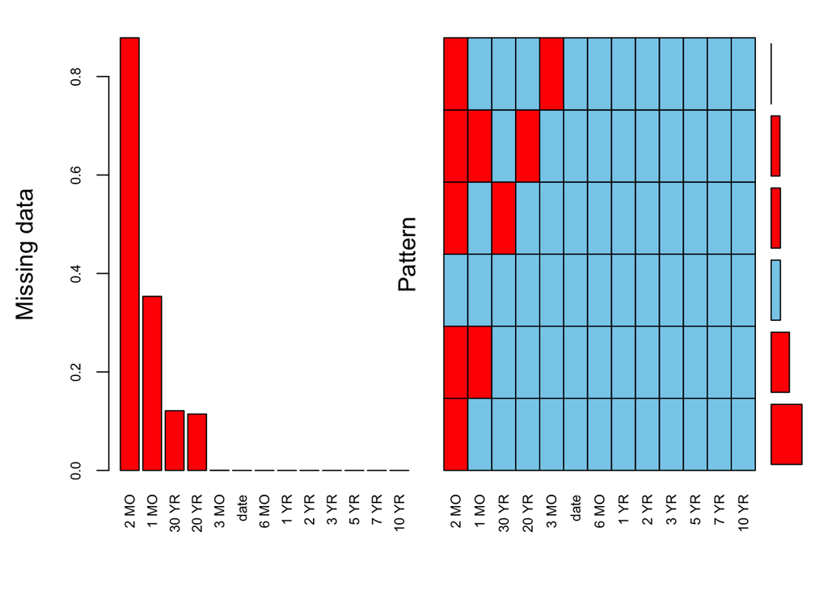

```
##
##  Variables sorted by number of missings:
##  Variable        Count
##      2 MO 0.8786585366
##      1 MO 0.3535365854
##     30 YR 0.1212195122
##     20 YR 0.1145121951
##      3 MO 0.0003658537
##      date 0.0000000000
##      6 MO 0.0000000000
##      1 YR 0.0000000000
##      2 YR 0.0000000000
##      3 YR 0.0000000000
##      5 YR 0.0000000000
##      7 YR 0.0000000000
##     10 YR 0.0000000000
```

```r
aggr(Data, numbers = TRUE, sortVars = TRUE, labels = names(Data),
     cex.axis = .7, gap = 1, ylab= c('Missing data','Pattern'))
```

```r
# NAs in 1-month, 2-month, 20-year, and 30-year, specially in first years
# except 2-month which is a new product and has almost complete NAs

Data = Data[,-3] # removes 2-month bill
```

The 2-month bill begins on October 16, 2018

## Descriptive analysis

To plot the evolution of each security in several panels, we need the data in tidy format

```r
DataTidy = gather(Data,"product", "yield", -date)
DataTidy$product <- factor(DataTidy$product, levels=unique(DataTidy$product))
head(DataTidy)
```

```
##         date product yield
## 1 1990-01-02    1 MO    NA
## 2 1990-01-03    1 MO    NA
## 3 1990-01-04    1 MO    NA
## 4 1990-01-05    1 MO    NA
## 5 1990-01-08    1 MO    NA
## 6 1990-01-09    1 MO    NA
```

```r
tail(DataTidy)
```

```
##             date product yield
## 90195 2022-09-29   30 YR  3.71
## 90196 2022-09-30   30 YR  3.79
## 90197 2022-10-03   30 YR  3.73
## 90198 2022-10-04   30 YR  3.70
## 90199 2022-10-05   30 YR  3.78
## 90200 2022-10-06   30 YR  3.81
```

Focus on the most recent data (from year 2000):

```r
DataTidy = filter(DataTidy, year(DataTidy$date)>2000)
Data = filter(Data, year(Data$date)>2000)
```

Get recession periods from FRED:

```r
getSymbols('USREC',src='FRED')
```

```
## [1] "USREC"
```

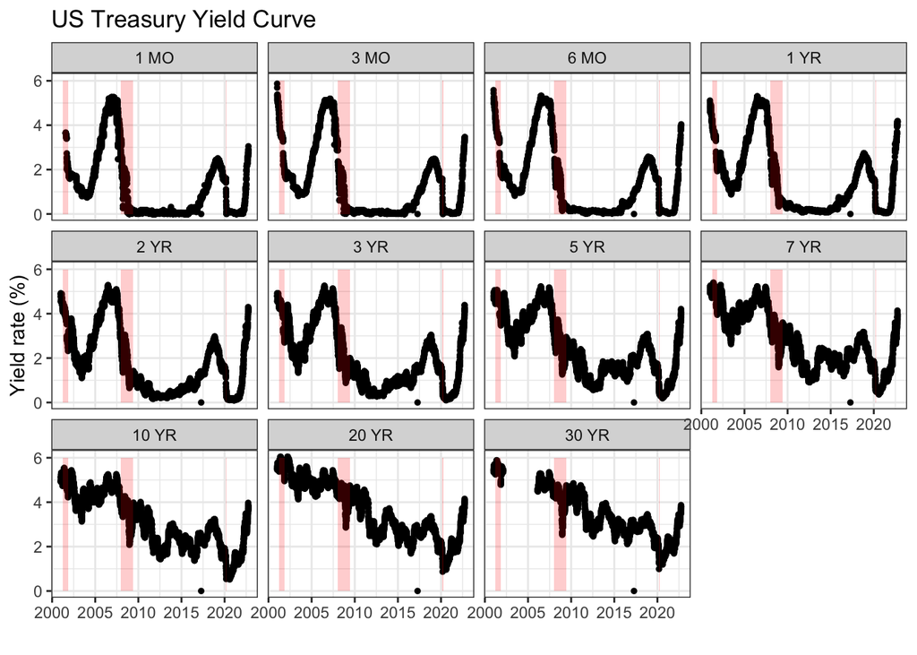

```r
start <- index(USREC[which(diff(USREC$USREC)==1)])
end   <- index(USREC[which(diff(USREC$USREC)==-1)-1])

rec.df <- data.frame(start=start, end=end[-1])
rec.df <- filter(rec.df, start >= min(Data$date))
# Done with recession

DataTidy %>%
  ggplot(aes(x=date, y=yield)) + geom_point(size=1) +
  theme_bw() + theme(legend.position="bottom") + scale_color_brewer(palette="Dark2") +
  geom_rect(data=rec.df, aes(x=NULL, y=NULL, xmin=start,xmax=end, ymin=0,ymax=6), fill="red", alpha=0.2) +
  facet_wrap(~product) + labs(title="US Treasury Yield Curve", x="", y="Yield rate (%)")
```

Some gaps (NAs), especially the 30-year bond was discontinued on February 18, 2002 and reintroduced on February 9, 2006

Short-term yields started to decrease from 2019, in 2020 the drop is very fast (coronavirus). Now they are increasing a lot!

Long-term yields decrease in the long term with noise, but after coronavirus recession they have started to increase

One outlier on 14-april-2017

Plot now the yield curve for the last dates

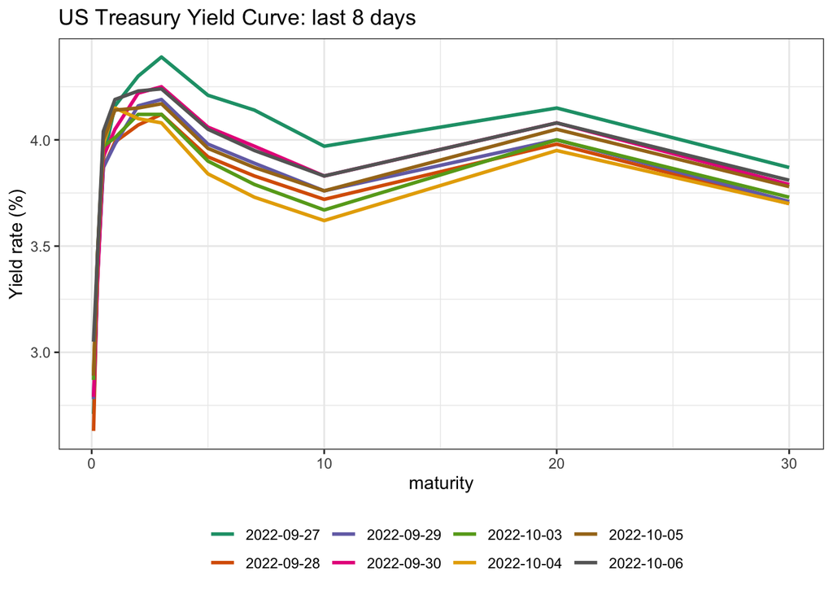

```r
last.date <- max(Data$date)

maturity = as.factor(c(0.08,0.25,0.5,1,2,3,5,7,10,20,30))
levels(DataTidy$product) = maturity

# Plot the yield curve for 8 last days:
DataTidy %>% filter(date > last.date-10) %>%
  ggplot(aes(as.numeric(as.character(product)), yield, color=factor(date))) + geom_line(size=1) +
  theme_bw() + theme(legend.position="bottom") + scale_color_brewer(palette="Dark2") +
  labs(title=paste0("US Treasury Yield Curve: ", "last 8 days"), x="maturity", y="Yield rate (%)", col="")
```

The curve is inverted these days